# IPF_paper_figure1

2023-09-25

# 1 general settings

```r
library(magrittr)
library(ComplexHeatmap)
library(ggplot2)

working.dir = "/home/jyu/rstudio/"

ms_dir = paste0(working.dir,"/IPF_manuscript/manuscriptV3/figures")
ms_date = "20230921"
```

## 1.1 color

```r
stage_color = c("Control" = "grey",
                "Early-IPF" = "#076B94",
                "Advanced-IPF" = "#C6A775")
```

# 2 20221017 clustering analysis of pulmonary function parameters

```r
input = readxl::read_xlsx(path = paste0(working.dir,"/IPF_manuscript/meta_data/prevalent_all_incident.xlsx"),sheet = "Sheet1")

input$medication_group = ifelse(input$medication == "no", "no", "yes")

# only focus on IPF patients and controls
input = input[input$Dx %in% c("IPF","Control"),]

input$genderNum = ifelse(input$Gender == "female", 0, 1)
input$smokingNum = ifelse(input$smoking == "nd",0,
                                ifelse(input$smoking == "ex",1,
                                       ifelse(input$smoking == "yes",2,3)))

input=input[!is.na(input$identifier),]

rownames(input) = input$identifier
library(Amelia)
# remove prevalent 2 patients which have no data for lung function parameters
input = input[!rownames(input) %in% c("IPF4","IPF2718174"),]
input[input=="nd"] = NA

## integrate FVC and VC information
input$FVCorVC_percent = ifelse(is.na(input$FVC_percent),input$VC_percent,input$FVC_percent)
```

## 2.1 select lung function para

```r
# input$FVCorVC_percent = ifelse(is.na(input$FVC_percent),input$VC_percent,input$FVC_percent)
# # cols.num <- c("Age","FVCorVC_percent","FEV1_percent","TLC_percent","DLCO_percent","pO2","pCO2")
# cols.num <- c("FVCorVC_percent","FEV1_percent","TLC_percent","DLCO_percent","pO2","pCO2")
#
# # test = subset(input,cohort=="prevalent")
# test = input[,cols.num]
# test <- sapply(test,as.numeric)
#
#
# # library("PerformanceAnalytics")
# # chart.Correlation(test, histogram=TRUE, pch=19)
#
# rm(test)
```

### 2.1.1 impute data

```r
# cols.num <- c("Age","FVCorVC_percent","FEV1_percent","TLC_percent","DLCO_percent","pO2","pCO2")
#
#
# test = input[,cols.num]
# test <- sapply(test,as.numeric)
# rownames(test) = input$identifier
# # rownames(test) = paste0("group",tmp_data$group,"_",rownames(tmp_data))
# impute_data = amelia(as.data.frame(test),m = 5,parallel = "multicore")
# impute_cluster = dist(scale(impute_data$imputations$imp5)) %>% hclust()
# # write.csv(impute_data$imputations$imp1,file = paste0(working.dir,"/clinical_phenotype/20221205_imputed_data_7parameters.csv"))
# rm(test)
```

### 2.1.2 clustering

```r
impute_data = read.csv(file = paste0(working.dir,"/IPF_manuscript/meta_data/20221205_imputed_data_7parameters.csv"),row.names = 1)
cols.num <- c("FVCorVC_percent","FEV1_percent","TLC_percent","DLCO_percent","pO2","pCO2")

impute_data = impute_data[,cols.num]

impute_cluster = dist(scale(impute_data)) %>% hclust()

# plot(impute_cluster)
#
p = ComplexHeatmap::Heatmap(scale(impute_data),
                            clustering_distance_rows = "euclidean",
                            clustering_distance_columns = "euclidean")

# p
```

### 2.1.3 save cluster information

it contains scaled values for all parameters

```r
p_matrix = p@matrix

p_order = ComplexHeatmap::row_order(p)
test = p_matrix[p_order,]

# write.csv(test,file = paste0(working.dir,"/20230605_scaledvalue_patient_stages.csv"))

rm(test,p,p_order,p_matrix,impute_cluster,impute_data,cols.num)
```

# 3 figure 1

## 3.1 figure 1B

split groups in cluster1

```r
impute_data1 = read.csv(file = paste0(working.dir,"/IPF_manuscript/manuscriptV3/meta_data/20230605_scaledvalue_patient_stages.csv"))
impute_data = impute_data1[,c("FVCorVC_percent","FEV1_percent","TLC_percent","DLCO_percent","pO2","pCO2")]
colnames(impute_data) = c("FVC","FEV1","TLC","DLCO","pO2","pCO2")

impute_data = sapply(impute_data,as.numeric)
rownames(impute_data) = rownames(impute_data1)

pnt_stage = impute_data1[,c("identifier","stage","diagnosis","death")]

pnt_stage$stage = factor(pnt_stage$stage,levels = c("Control","Early-IPF","Advanced-IPF"))

row_ha = ComplexHeatmap::columnAnnotation(Diagnosis = pnt_stage$diagnosis,
                                          # Death = pnt_stage$death,
                                          Group = pnt_stage$stage,
                                       col=list(Diagnosis = c("Control" = "grey","IPF" = "#A1756D"),
                                                # Death = c("yes" = "black", "no" = "white","nd"="grey"),
                                                # Group = c("Control/early-IPF" = "#076B94","Advanced-IPF" = "#C6A775")),
                                                Group = stage_color
                                                ),
                                       annotation_name_side = "left",annotation_name_gp = gpar(fontsize=8),
                                       annotation_legend_param = list(title_gp = gpar(fontsize=8),labels_gp = gpar(fontsize=8))
                                       )

lgd = ComplexHeatmap::Legend(col_fun = circlize::colorRamp2(c(-4,0,4),c("lightblue","white","red")),
                             title = "Scaled value",
                             at = c(-4,-2,0,2,4),
                             direction = "horizontal",
                             title_position = "lefttop",
                             title_gp = gpar(fontsize=8),
                             legend_gp = gpar(fontsize=8),
                             labels_gp = gpar(fontsize=8)
                             )

pdf(file = paste0(ms_dir,"/fig1b.para.heatmap_",ms_date,"V3.pdf"),paper = "a4",width = 6,height = 4)

grid.newpage
```

[output not shown]

```r
# pushViewport(viewport(layout = grid.layout(nr=2,nc=1)))

pushViewport(viewport(x=0.5,y=0.6,width = 0.7,height = 0.6))
draw(ComplexHeatmap::Heatmap(t(impute_data),
                             row_names_gp = gpar(fontsize=8),
                        clustering_distance_rows = "euclidean",
                        clustering_distance_columns = "euclidean",
                        name = "Scaled value",
                        cluster_rows = FALSE,
                        cluster_columns = TRUE,
                        top_annotation = row_ha,
                        show_heatmap_legend = FALSE,
                        column_title_side = "top",
                        row_names_side = "left",
                        show_column_names = FALSE,
                        col = colorRampPalette(c("lightblue","white","red"))(200)),
     newpage = FALSE
)
upViewport()

pushViewport(viewport(x=0.5,y=0.25,width = 0.5,height = 0.5))
# par(mar=c(1,0,0,1))
grid.draw(lgd)
upViewport()

dev.off()
```

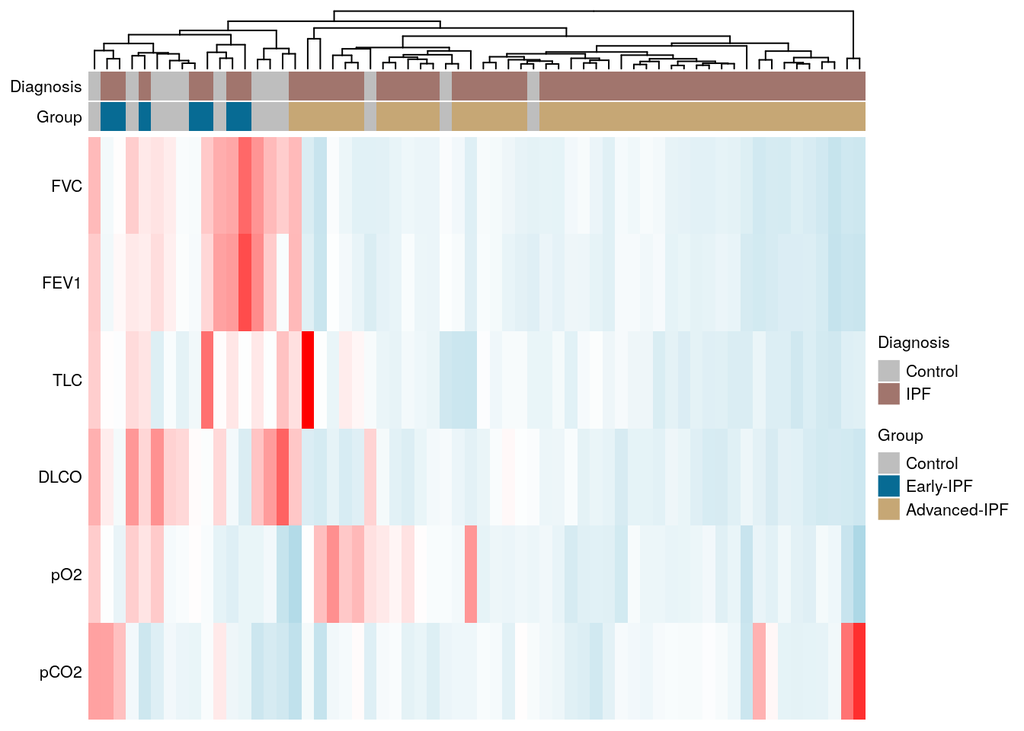

```r
draw(ComplexHeatmap::Heatmap(t(impute_data),
                             row_names_gp = gpar(fontsize=8),
                        clustering_distance_rows = "euclidean",
                        clustering_distance_columns = "euclidean",
                        name = "Scaled value",
                        cluster_rows = FALSE,
                        cluster_columns = TRUE,
                        top_annotation = row_ha,
                        show_heatmap_legend = FALSE,
                        column_title_side = "top",
                        row_names_side = "left",
                        show_column_names = FALSE,
                        col = colorRampPalette(c("lightblue","white","red"))(200)),
     newpage = FALSE
)
```

```r
rm(pnt_stage, impute_data, row_ha,lgd)
```

## 3.2 figure 1C

```r
pnt_stage = read.csv(file = paste0(working.dir,"/IPF_manuscript/manuscriptV3/meta_data/20230605_scaledvalue_patient_stages.csv"))

pnt_stage = merge(pnt_stage,input,by.x="identifier",by.y="identifier")


pdf(file = paste0(ms_dir,"/fig1c.boxplotFEV1_signif_",ms_date,".pdf"),paper = "a4",width = 2.5,height = 1)

cols.num <- c("Age.y","Opacity","OpacityScore","AvgGroundglass","AvgReticular","AvgnormalLung","VC","VC_percent","FEV1","FEV1_percent.y","TLC_percent.y","TLC","DLCO_percent.y","pO2.y","pCO2.y")

# for(i in cols.num){
i = "FEV1_percent.y"
test = pnt_stage[!is.na(pnt_stage[,i]),]

test = test[,c("identifier",i,"stage")]
colnames(test) = c("identifier","para","stage")

test$stage = factor(test$stage,levels = c("Advanced-IPF","Early-IPF","Control"))

my_comparisons <- list(
  # c("Control","Early-IPF"),
  c("Control","Advanced-IPF"),
  c("Early-IPF","Advanced-IPF")
                        )


p =  test  %>%
  ggplot(.,aes(x=stage,y=as.numeric(para),color=stage))+
  geom_boxplot(outlier.shape=NA,outlier.size=4)+
  geom_dotplot(aes(y=as.numeric(para)),fill="white",binaxis='y', stackdir='center', dotsize=0.7)+
  # ggpubr::stat_compare_means(aes(label = ..p.format..),comparisons = my_comparisons,method = "t.test",hide.ns = TRUE)+
  ggpubr::stat_compare_means(aes(label = ..p.signif..),comparisons = my_comparisons,method = "t.test",hide.ns = TRUE,bracket.size = 0.5,vjust = 0.6)+
  scale_color_manual(values = stage_color)+
  theme_classic()+
  ylim(c(0,230))+
  scale_y_continuous(position = "right")+
  ylab(label = paste0("FEV1 predicted value (%)"))+
  xlab("")+
  coord_flip()+
   theme(axis.text.x = element_text(size = 8,colour = "black"),
         axis.text.y = element_text(size = 8,colour = "black"),
         axis.title.y = element_text(size = 8,colour = "black"),
         title = element_text(size = 8,colour = "black"),
         legend.position = "NULL")
print(p)
# }

dev.off()
```

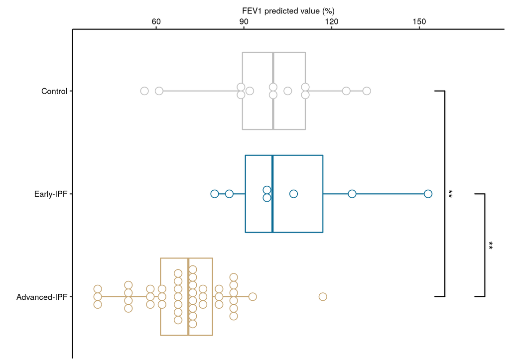

```r
p
```

```r
rm(pnt_stage,cols.num,i,test,my_comparisons,p)
```

## 3.3 figure 1D

```r
pnt_stage = read.csv(file = paste0(working.dir,"/IPF_manuscript/manuscriptV3/meta_data/20230605_scaledvalue_patient_stages.csv"))

pnt_stage = merge(pnt_stage,input,by.x="identifier",by.y="identifier")


pdf(file = paste0(ms_dir,"/fig1d.boxplotDLCO_",ms_date,".pdf"),paper = "a4",width = 2.5,height = 1)

cols.num <- c("Age.y","Opacity","OpacityScore","AvgGroundglass","AvgReticular","AvgnormalLung","VC","VC_percent","FEV1","FEV1_percent.y","TLC_percent.y","TLC","DLCO_percent.y","pO2.y","pCO2.y")
# for(i in cols.num){
i = "DLCO_percent.y"
test = pnt_stage[!is.na(pnt_stage[,i]),]

test = test[,c("identifier",i,"stage")]
colnames(test) = c("identifier","para","stage")

test$stage = factor(test$stage,levels = c("Advanced-IPF","Early-IPF","Control"))

my_comparisons <- list(
  c("Control","Early-IPF"),
  c("Control","Advanced-IPF"),
  c("Early-IPF","Advanced-IPF")
                        )


p =  test  %>%
  ggplot(.,aes(x=stage,y=as.numeric(para),color=stage))+
  geom_boxplot(outlier.shape=NA,outlier.size=4)+
  geom_dotplot(aes(y=as.numeric(para)),fill="white",binaxis='y', stackdir='center', dotsize=0.7)+
  # ggpubr::stat_compare_means(aes(label = ..p.format..),comparisons = my_comparisons,method = "t.test",hide.ns = TRUE)+
  ggpubr::stat_compare_means(aes(label = ..p.signif..),comparisons = my_comparisons,method = "t.test",hide.ns = TRUE,bracket.size = 0.5,vjust = 0.6)+
  scale_color_manual(values = stage_color)+
  theme_classic()+
  ylim(c(0,230))+
  scale_y_continuous(position = "right")+
  ylab(label = paste0("DLco predicted value (%)"))+
  xlab("")+
  coord_flip()+
   theme(axis.text.x = element_text(size = 8,colour = "black"),
         axis.text.y = element_text(size = 8,colour = "black"),
         axis.title.y = element_text(size = 8,colour = "black"),
         title = element_text(size = 8,colour = "black"),
         legend.position = "NULL")
print(p)
# }

dev.off()
```

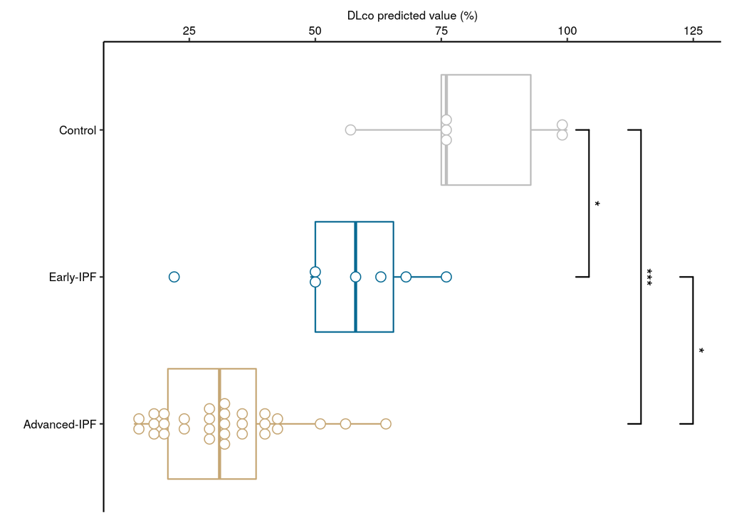

```r
p
```

```r
rm(pnt_stage,cols.num,i,test,my_comparisons,p)
```

## 3.4 figure 1F

### 3.4.1 load seurat object

```r
library(Seurat)
ipf_seu = readRDS(file=paste0(working.dir,"/IPF_manuscript/data/ILD_combined_sct_rpca20230720.rds"))

ipf_seu$IPFgroup = factor(ipf_seu$IPFgroup,levels = c("Control","Early-IPF","Advanced-IPF"))

## export tables4
#
# tmpdata = table(ipf_seu$pnt_in_paper,ipf_seu$subcluster)
# tmpdata1 = as.matrix.data.frame(tmpdata)
# rownames(tmpdata1) = rownames(tmpdata)
# colnames(tmpdata1) = colnames(tmpdata)
#
# write.csv(tmpdata1,paste0(working.dir,"/IPF_manuscript/manuscript/tables4.csv"))
#
# rm(tmpdata,tmpdata1)
```

### 3.4.2 plot

```r
Idents(ipf_seu) = "subcluster"

ipf_seu = RenameIdents(ipf_seu,
                          "0" = "Macrophage",
                             "4_0" = "Macrophage",
                             "4_1" = "Macrophage",
                             "4_2" = "Macrophage",
                             "5" = "T/NK cell",
                             "6" = "Macrophage",
                             "7" = "Macrophage",
                             "8" = "Macrophage",
                             "9" = "T/NK cell",
                             "10" = "Macrophage",
                             "11" = "Macrophage",
                             "12" = "Neutrophil",
                             "13" = "Macrophage",
                             "14" = "T/NK cell",
                             "15" = "Epithelial cell",
                             "16" = "Epithelial cell",
                             "17" = "DC",
                             "19" = "DC",
                             "20" = "Macrophage",
                             "21" = "Mast cell",
                             "22" = "Eosinophil",
                             "24" = "Epithelial cell")



seurat_cluster_color =  c("Macrophage" = "#8DD3C7",
                             "DC" = "#E9967A",
                             "Neutrophil" = "#7B68EE",
                             "Eosinophil" = "purple",
                             "Mast cell" = "red",
                             "T/NK cell" = "green",
                             "Epithelial cell" = "black")

pdf(file = paste0(ms_dir,"/fig1f_major_umap_",ms_date,".pdf"),paper = "a4",width = 3.2,height = 2.5 )

p = DimPlot(ipf_seu,dims = c(1,3),
        # group.by = "subcluster",
        cols = seurat_cluster_color,
        raster = TRUE,repel = TRUE,raster.dpi = c(1024,1024),pt.size = 3,
        label = FALSE,label.size = 3)+
  # ggrepel::geom_label_repel(box.padding = 0.5, max.overlaps = Inf)+
  labs(title = "All cells (n=68,886)")+
  theme(axis.line = element_blank(),
        axis.text = element_blank(),
        axis.ticks = element_blank(),
        axis.title = element_text(size=7),
        plot.title = element_text(hjust=0.5,face = "plain",size = 8),
        panel.border = element_rect(color = "black",size=0.3,fill = NA),
        # legend.position = "none")
        legend.text = element_text(size = 8,colour = "black"),
        legend.text.align = 0,
        legend.key.size = unit(0.5,"cm"),
        legend.title = element_text(size = 8),
        legend.box.margin = margin(0,0,0,-11))
plot(p)
dev.off()
```

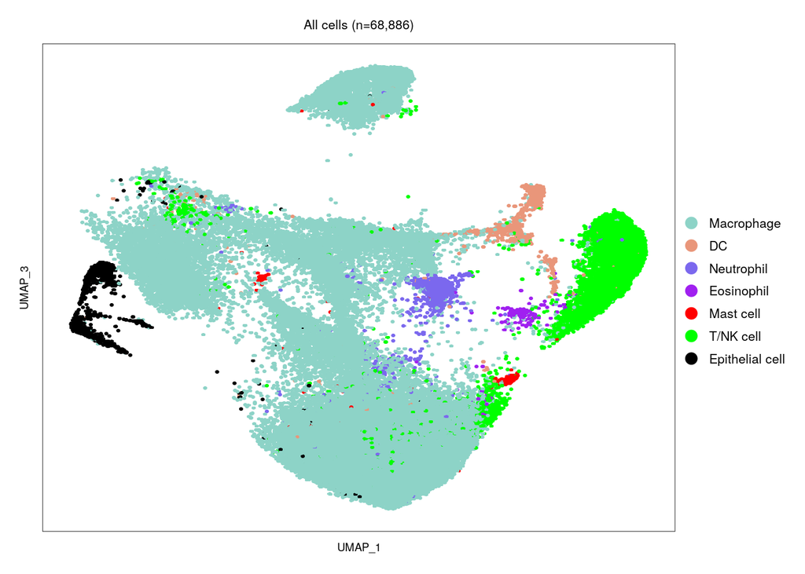

```r
p
```

```r
rm(p)
```

## 3.5 figure 1G

### 3.5.1 load seurat object

```r
# Idents(ipf_seu) = "seurat_clusters"
# ipf_seu_mac = subset(ipf_seu,idents = c(0,4,6,7,8,10,11,13,20))
# ipf_seu_mac <- RunUMAP(ipf_seu_mac,
#                             reduction = "pca",
#                             dims = 1:30,
#                             n.neighbors = 30,
#                             min.dist = 0.000001,
#                             n.components = 3,
#                             a = 1,
#                             b = 0.9,
#                             spread = 4)
#
# DimPlot(ipf_seu_mac,dims = c(2,3))
#
# saveRDS(ipf_seu_mac, file = paste0(working.dir,"/IPF_manuscript/data/ILD_combined_sct_rpca20230720_mac.rds"))
ipf_seu_mac = readRDS(file=paste0(working.dir,"/IPF_manuscript/data/ILD_combined_sct_rpca20230720_mac.rds"))

Idents(ipf_seu_mac) = "subcluster"

##use same colors for cluster 7, 13, 20
mac_color = c("0" = "#344e41",
                             "4_0" = "#FF1493",
                         "4_1" = "#48cae4",
                         "4_2" = "#ffafcc",
                             "6" = "#BDE4C8",
                             "7" = "#6a994e",
                             "8" = "#73BCEB",
                             "10" = "#00b4d8",
                             "11" = "#467599",
                             "13" = "#6a994e",
                             "20" = "#6a994e")


mac_label = c("0" = expression(Alveolar*"-"*M*phi1*(0)),
                             "4_0" = "Monocyte(4_0)",
                             "4_1" = expression(RNASE1^"+"*M*phi1*(4*"_"*1)),
                             "4_2" = expression(SPP1^"+"*M*phi1*(4*"_"*2)),
                             "6" = expression(S100A11^"+"*M*phi1*(6)),
                             "7" = expression(MKI67^"+"*M*phi1*(7*","*13*","*20)),
                             "8" = expression(CXCL10^"+"*M*phi1*(8)),
                             "10" = expression(TNFAIP6^"+"*M*phi1*(10)),
                             "11" = expression(NEAT1^"+"*M*phi1*(11)),
                             "13" = expression(MKI67^"+"*M*phi1*(7*","*13*","*20)),
                             "20" = expression(MKI67^"+"*M*phi1*(7*","*13*","*20)))
```

### 3.5.2 plot

```r
pdf(file = paste0(ms_dir,"/fig1g_mac_umap_",ms_date,".pdf"),paper = "a4",width = 4,height = 2.5 )

p = DimPlot(ipf_seu_mac,
        dims = c(2,3),
        group.by = "subcluster",
        # split.by = "major",
        # cols = color_majorcelltype,
        cols = mac_color,
        # ncol = 3,
        # shuffle = TRUE,
        raster = TRUE,
        raster.dpi = c(2048,2048),
        label = TRUE,
        repel = TRUE,
        pt.size = 3,
        label.size = 3.5)+
  labs(title = "Macrophage (n=54,360)")+
  # geom_text(data=data.frame(),aes(label = "56,627 cells",x=-Inf,y=Inf),hjust=-0.1,vjust=19,size=3)+

      theme(axis.line = element_blank(),
        axis.text = element_blank(),
        axis.ticks = element_blank(),
        axis.title = element_text(size=8),
        plot.title = element_text(hjust=0.5,face = "plain",size = 8),
        panel.border = element_rect(color = "black",size=0.8,fill = NA),
        legend.text = element_text(size = 8,colour = "black"),
        legend.text.align = 0,
        legend.key.size = unit(0.5,"cm"),
        legend.title = element_text(size = 8)
          # legend.text = element_text(size = 20),
          # legend.key.size  = unit(1.3,"cm")
        )+
  scale_color_manual(name = "Cluster",
                     labels = mac_label[1:9],
                     values = mac_color[1:9])
```

[output not shown]

```r
plot(p)
dev.off()
```

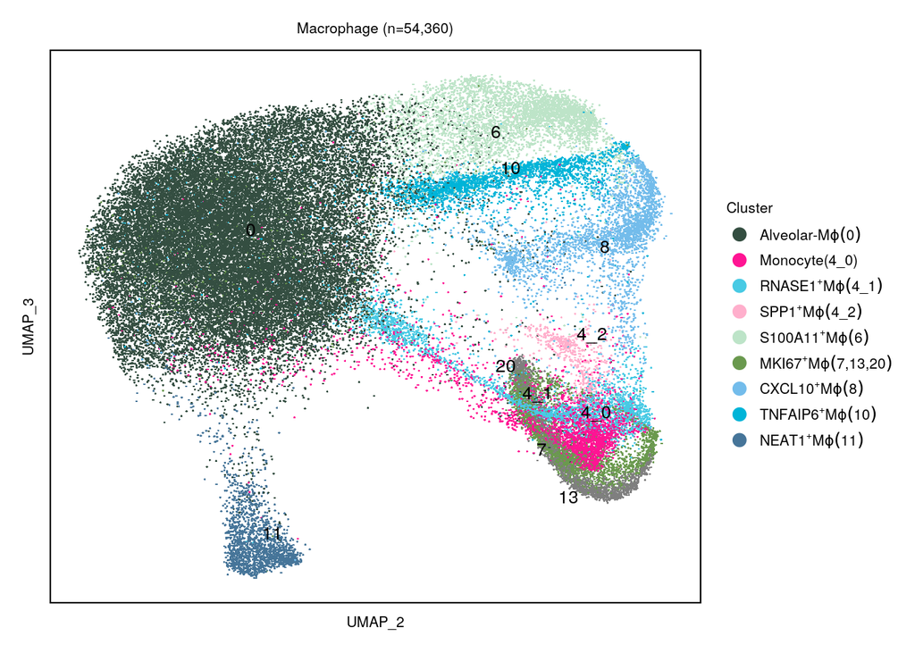

```r
p
```

```r
rm(p)
```

## 3.6 figure 1H

add AM degs into the figure

```r
library(tidyverse)
```

```r
# run1to4_ck_ipf_n_copd_ck_deg_subcluster = FindAllMarkers(ipf_seu_mac)
# write.csv(run1to4_ck_ipf_n_copd_ck_deg_subcluster,file = paste0(working.dir,"/IPF_manuscript/meta_data/ILD_combined_sct_rpca20230720_mac_subcluster_deg.csv"))

run1to4_ck_ipf_n_copd_ck_deg_subcluster = read.csv(file = paste0(working.dir,"/IPF_manuscript/manuscriptV3/meta_data/ILD_combined_sct_rpca20230720_mac_subcluster_deg.csv"))
tmp_genes = run1to4_ck_ipf_n_copd_ck_deg_subcluster %>% subset(.,avg_log2FC > 0.5) %>% group_by(cluster) %>% top_n(n = 5, wt = avg_log2FC)
tmp_genes = tmp_genes[tmp_genes$cluster %in% c(0,"4_0","4_1","4_2",6,8,10,11,13),]

tmp_genes = tmp_genes[order(tmp_genes$avg_log2FC,decreasing = TRUE),]

tmp_genes$cluster = factor(tmp_genes$cluster,levels = c(0,"4_0","4_1","4_2",6,8,10,11,13) )
tmp_genes = tmp_genes[order(tmp_genes$cluster,decreasing = FALSE),]
tmp_genes = c(unique(tmp_genes$gene))

ipf_seu_mac$subcluster1 = ifelse(ipf_seu_mac$subcluster %in% c(13,20),"7",as.character(ipf_seu_mac$subcluster))
ipf_seu_mac$subcluster1 = factor(ipf_seu_mac$subcluster1,levels = c(0,"4_0","4_1","4_2",6,8,10,11,7))

pdf(file = paste0(ms_dir,"/fig1h_mac_deg_",ms_date,".pdf"),paper = "a4",width = 7,height = 3 )

## add mac genes
tmp_genes = c("FABP4","MARCO","PPARG","FTL",tmp_genes) %>% unique()

p = DotPlot(ipf_seu_mac,features = tmp_genes,
        group.by = "subcluster1",assay = "RNA",scale = TRUE)

ggplot(p$data,aes(x=features.plot,y=id))+
  geom_point(aes(size=pct.exp,color=avg.exp.scaled))+
  scale_y_discrete(labels = mac_label)+
  scale_color_gradientn(colours  = c("#a8dadc","white","#9d0208"))+
  # coord_flip()+
  xlab("")+
  ylab("")+
  theme_classic()+
  theme(axis.text.x = element_text(angle = 90, vjust = 0.5, hjust=1),
        axis.text = element_text(size = 8),
        axis.line = element_blank(),
        # axis.ticks.y = element_blank(),
        # axis.text.y = element_blank(),
        panel.border = element_rect(color = "black",size=0.8,fill = NA),
        legend.position = "right",
        legend.text = element_text(size = 8,colour = "black"),
        legend.title = element_text(size = 8,colour = "black"),
        legend.box = "vertical",
        legend.box.margin = margin(-20,-20,-20,-11))+
  guides(size = guide_legend(order = 2,title = "% of exp. cells"),
         color = guide_colorbar(order = 2,title = "Gene expression",barwidth = 0.5,barheight = 3))

plot(p)
dev.off()
```

[figure not shown]

```r
p
```

```r
rm(tmp_genes,p)
```

R version 4.1.3 (2022-03-10) Platform: x86_64-pc-linux-gnu (64-bit) Running under: Ubuntu 20.04.4 LTS

Matrix products: default BLAS/LAPACK: /usr/lib/x86_64-linux-gnu/openblas-pthread/libopenblasp-r0.3.8.so

locale: [1] C

attached base packages: [1] grid stats graphics grDevices utils datasets methods  
[8] base

other attached packages: [1] forcats_0.5.1 stringr_1.4.0 dplyr_1.0.8  
[4] purrr_0.3.4 readr_2.1.2 tidyr_1.2.0  
[7] tibble_3.1.6 tidyverse_1.3.1 SeuratObject_4.0.4  
[10] Seurat_4.1.0 Amelia_1.8.0 Rcpp_1.0.8.3  
[13] ggplot2_3.3.5 ComplexHeatmap_2.10.0 magrittr_2.0.3